# 02_Exploration

# 1 Introduction

# 2 General Data Summaries

## 2.1 Study Period

I.E., what dates/years are covered by the time series data?

```r
range(study_dat$date_sampled)
```

```
## [1] "2004-02-23" "2026-05-14"
```

We have data spanning Feb of 2004 to May of 2026.

How do eighthr ones look in terms of time?

```r
study_dat |>
  filter(eighthr == "Y") |>
  summarize(mean = mean(time), sd = sd(time))
```

```
##       mean        sd
## 1 7.459559 0.5312874
```

## 2.2 Observations by Year

Let’s start by seeing how many measurements were recorded by year:

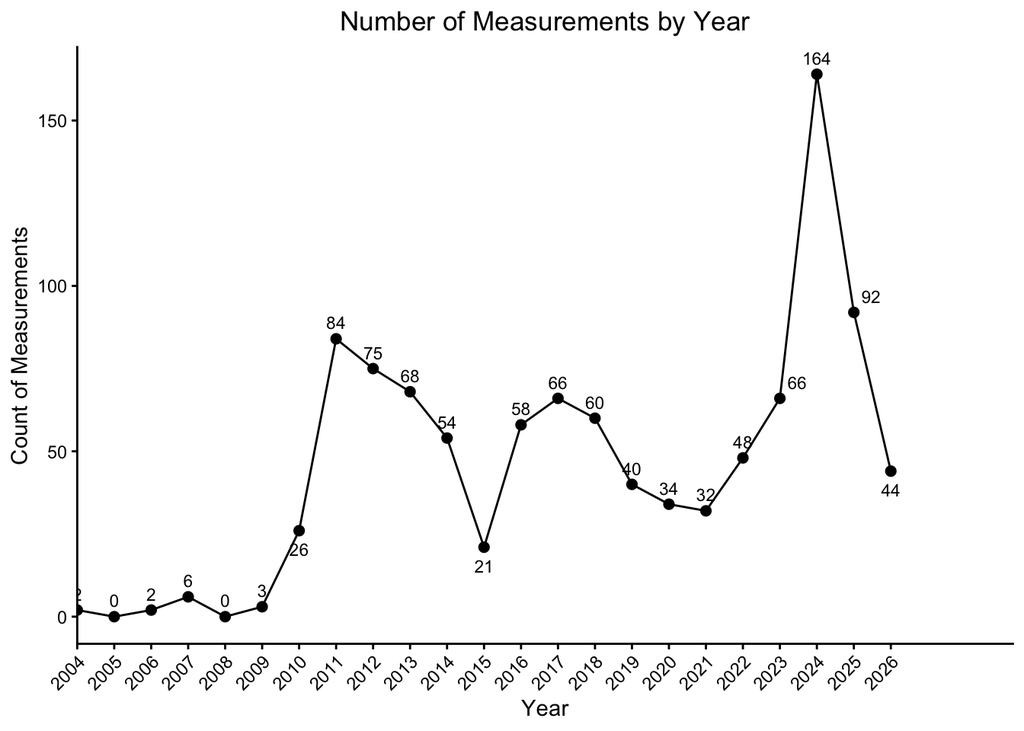

```r
study_dat |>
  group_by(year) |>
  summarize(measurements_in_year = n(), .groups = 'drop') |>
  mutate(year = as.numeric(as.character(year))) |>
  complete(year = full_seq(year, 1),
           fill = list(measurements_in_year = 0)) |>
  mutate(
    label_vjust = case_when(
      year %in% c(2010, 2015, 2026) ~ 2,  # Below
      TRUE ~ -0.8  # Above (default)
    ),
    label_hjust = case_when(
      year %in% c(2025,2023) ~ -0.4,  # More to the right
      TRUE ~ 0.5  # Center (default)
    )
  ) |>
  ggplot(aes(x = year, y = measurements_in_year)) +
  geom_point(size = 2) +
  geom_line() +
  geom_text(aes(label = measurements_in_year, vjust = label_vjust, hjust = label_hjust),
            size = 3) +
  labs(
    title = "Number of Measurements by Year",
    x = "Year",
    y = "Count of Measurements"
  ) +
  scale_x_continuous(
    breaks = seq(2004, 2026, 1),
    expand = expansion(mult = c(0, 0.15))
  ) +
  theme_classic() +
  theme(
    axis.text.x = element_text(angle = 45, hjust = 1, vjust = 1),
     plot.title = element_text(hjust = 0.5)
  )
```

We have the most observations in 2024. We are also missing data for the year 2005.

```r
summary(study_dat$year)
```

```
## 2004 2006 2007 2009 2010 2011 2012 2013 2014 2015 2016 2017 2018 2019 2020 2021
##    2    2    6    3   26   84   75   68   54   21   58   66   60   40   34   32
## 2022 2023 2024 2025 2026
##   48   66  164   92   44
```

## 2.3 Respirable silica by year

Let’s plot our respirable silica concentration measurements through our study period:

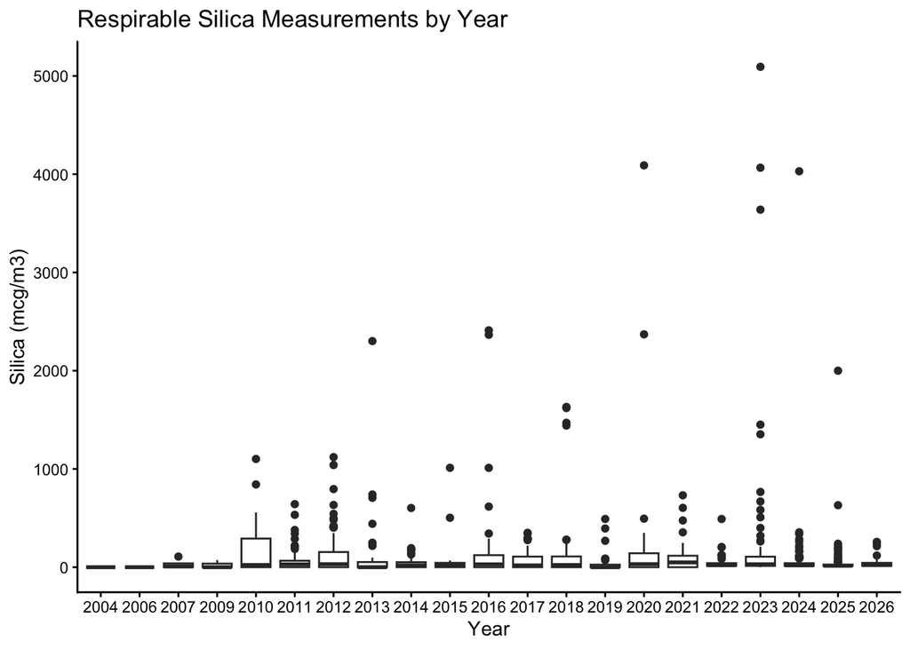

```r
ggplot(data = study_dat, aes(x = year, y = silica_conc))+
  geom_boxplot()+
  labs(title = "Respirable Silica Measurements by Year", x = "Year", y = "Silica (mcg/m3)") +
  theme_classic()
```

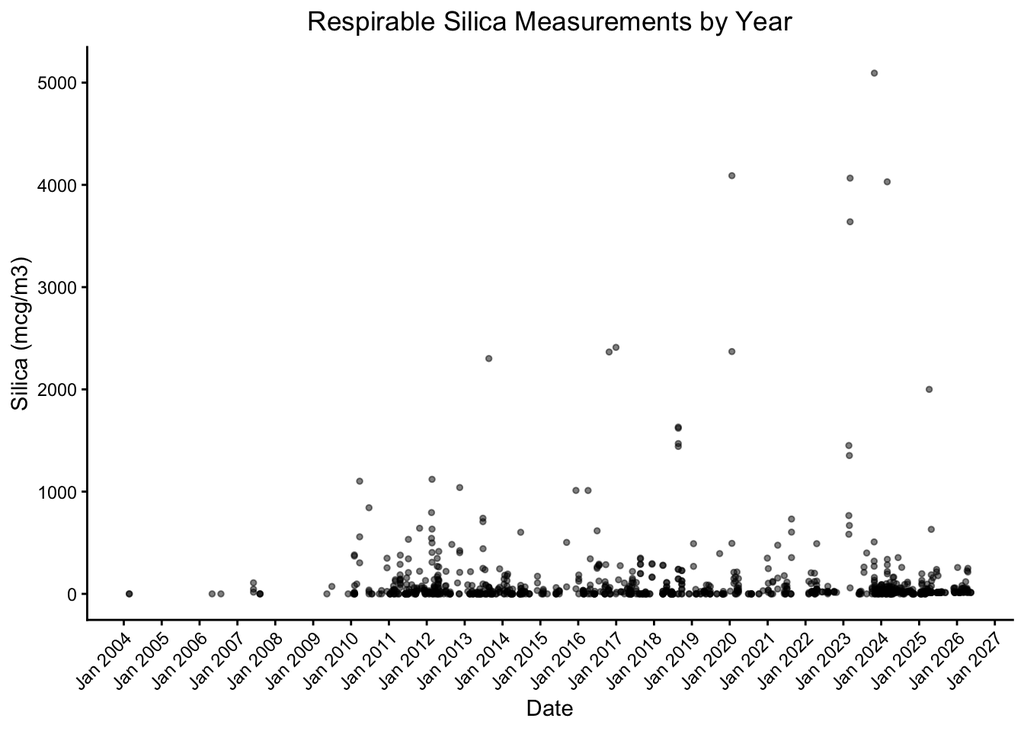

```r
#same, this time by date

ggplot(data = study_dat, aes(x = date_sampled, y = silica_conc)) +
  geom_point(size=1, alpha = 0.5) +
  scale_x_date(date_breaks = "year", date_labels = "%b %Y") +
  labs(
    title = "Respirable Silica Measurements by Year",
    x = "Date",
    y = "Silica (mcg/m3)"
  )+
  theme_classic()+
   theme(axis.text.x = element_text(angle = 45, hjust = 1),
          plot.title = element_text(hjust = 0.5))
```

Let’s try adding in a smooth line to see if there are any apparent long-term patterns:

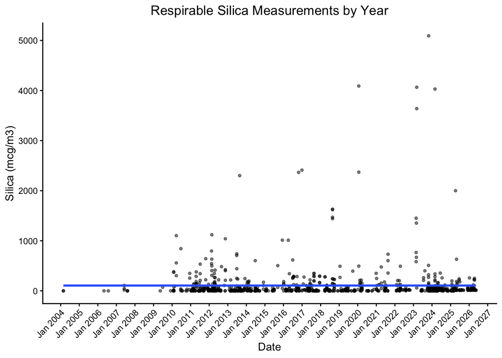

```r
ggplot(data = study_dat, aes(x = date_sampled, y = silica_conc)) +
  geom_point(size=1, alpha = 0.5) +
  geom_smooth()+
  scale_x_date(date_breaks = "year", date_labels = "%b %Y") +
  labs(
    title = "Respirable Silica Measurements by Year",
    x = "Date",
    y = "Silica (mcg/m3)"
  )+
  theme_classic()+
   theme(axis.text.x = element_text(angle = 45, hjust = 1),
          plot.title = element_text(hjust = 0.5))
```

This may not be possible to see or use, as we may not have enough observations to appropriately fit our time series with year. We can try “zooming in”:

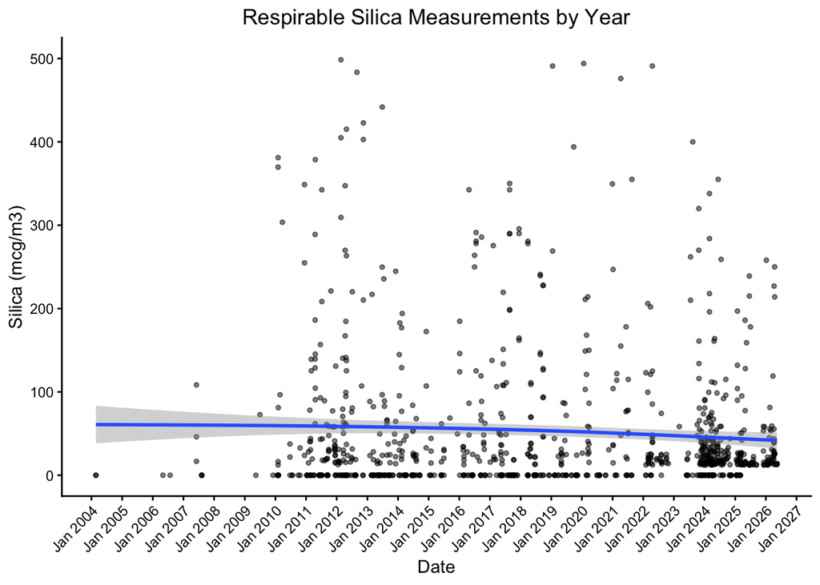

```r
ggplot(data = study_dat, aes(x = date_sampled, y = silica_conc)) +
  geom_point(size=1, alpha = 0.5) +
  geom_smooth()+
  scale_x_date(date_breaks = "year", date_labels = "%b %Y") +
  labs(
    title = "Respirable Silica Measurements by Year",
    x = "Date",
    y = "Silica (mcg/m3)"
  )+
  theme_classic()+
   theme(axis.text.x = element_text(angle = 45, hjust = 1),
          plot.title = element_text(hjust = 0.5)) +
scale_y_continuous(
    limits = c(0, 500),
    breaks = seq(0, 500, by = 100)
  )
```

Interesting, it looks like there is no clear trend here. We could attempt a nonlinear model?

Also, there does not appear to be any seasonality in our data.

Let’s add in our regulatory levels, and zoom in on our graph to see the patterns easier:

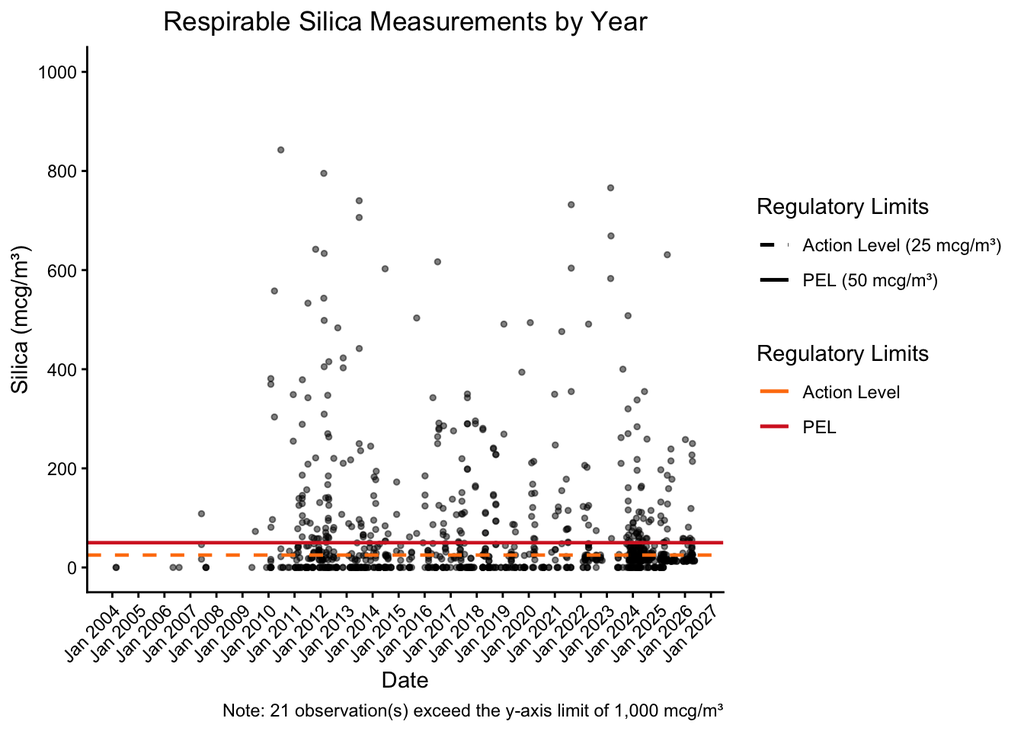

```r
# Counting the observations outside the graphical limits
n_outside <- sum(study_dat$silica_conc > 1000, na.rm = TRUE)

#Graph:

ggplot(data = study_dat, aes(x = date_sampled, y = silica_conc)) +
  geom_point(size = 1, alpha = 0.5) +

  #regulatory references
  geom_hline(aes(yintercept = 50, linetype = "PEL (50 mcg/m³)", color = "PEL"),
             linewidth = 0.8, show.legend = TRUE) +
  geom_hline(aes(yintercept = 25, linetype = "Action Level (25 mcg/m³)", color = "Action Level"),
             linewidth = 0.8, show.legend = TRUE) +

  # reducing scale of graphs
  scale_y_continuous(
    limits = c(0, 1000),
    breaks = seq(0, 1000, by = 200)
  ) +

  scale_x_date(date_breaks = "year", date_labels = "%b %Y") +

  # Coloring reference lines
  scale_color_manual(
    values = c("PEL" = "#d62728", "Action Level" = "#ff7f0e"),
    name = "Regulatory Limits"
  ) +
  scale_linetype_manual(
    values = c("PEL (50 mcg/m³)" = "solid", "Action Level (25 mcg/m³)" = "dashed"),
    name = "Regulatory Limits"
  ) +

  labs(
    title = "Respirable Silica Measurements by Year",
    x = "Date",
    y = "Silica (mcg/m³)",
    caption = paste0("Note: ", n_outside, " observation(s) exceed the y-axis limit of 1,000 mcg/m³")
  ) +

  theme_classic() +
  theme(
    axis.text.x = element_text(angle = 45, hjust = 1),
    legend.position = "right",
     plot.title = element_text(hjust = 0.5)
  )
```

Let’s investigate how our data differs depending on if it was taken from the IMIS code of 9000, or if we did the calculation to get the respirable silica concentration:

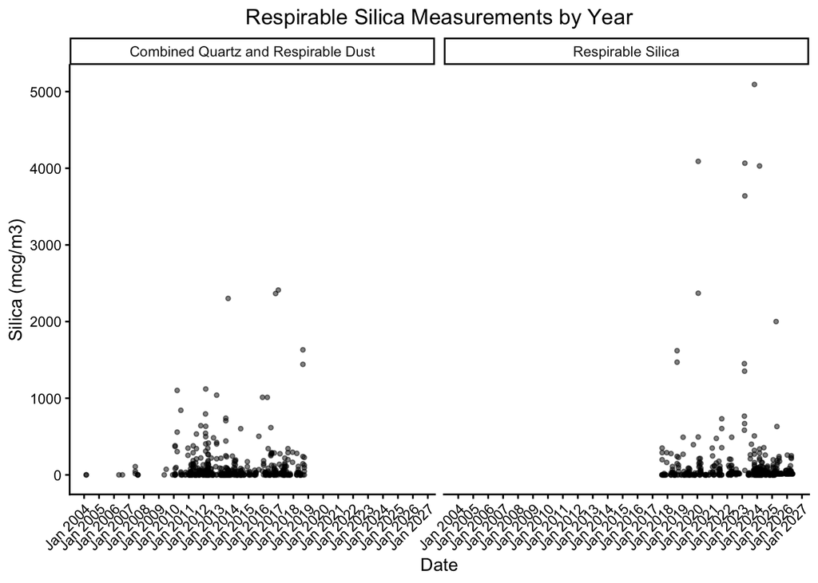

```r
#version where we facet by IMIS code
study_dat <- study_dat |>
  mutate(imis = factor(imis, levels = c("9010_9130", "9000"),
                       labels = c("Combined Quartz and Respirable Dust", "Respirable Silica")))

ggplot(data = study_dat, aes(x = date_sampled, y = silica_conc)) +
  geom_point(size=1, alpha = 0.5) +
  facet_grid(. ~ imis)+
  scale_x_date(date_breaks = "year", date_labels = "%b %Y") +
  labs(
    title = "Respirable Silica Measurements by Year",
    x = "Date",
    y = "Silica (mcg/m3)"
  )+
  theme_classic()+
   theme(axis.text.x = element_text(angle = 45, hjust = 1),
          plot.title = element_text(hjust = 0.5))
```

#PEL Analysis

Let’s look at this a bit differently, with a bar graph that tells us how many observations exceed the PEL per year:

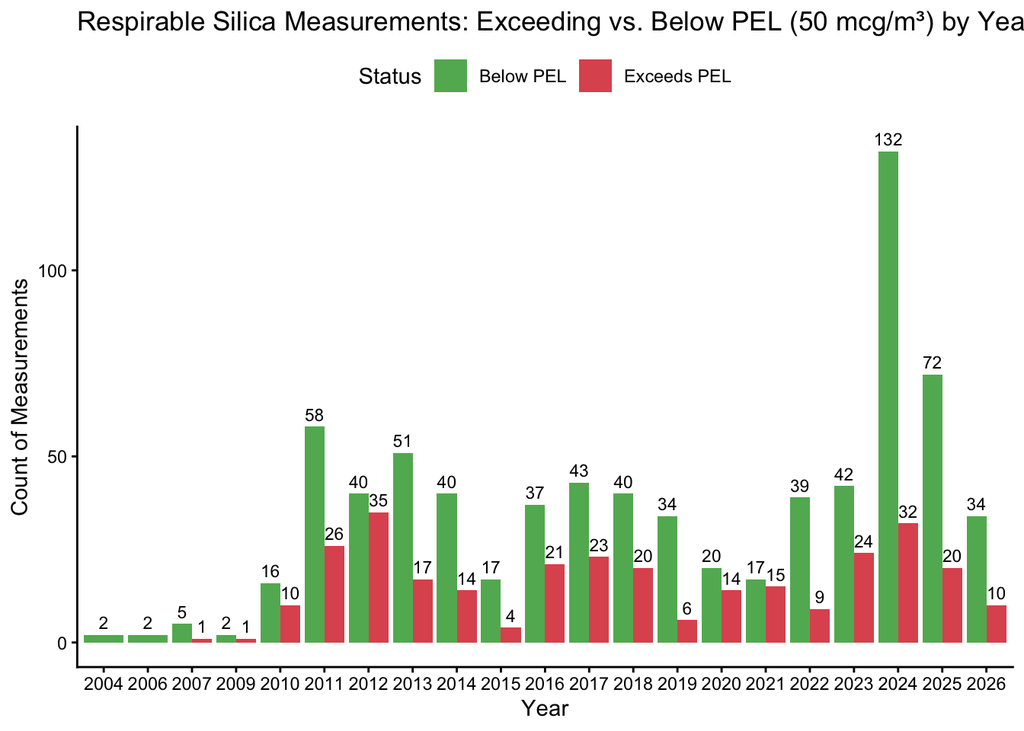

```r
 study_dat <- study_dat |>
  mutate(over_PEL = silica_conc >= 50)

study_dat |>
  count(year, over_PEL) |>
  mutate(PEL_status = if_else(over_PEL, "Exceeds PEL", "Below PEL")) |>
  ggplot(aes(x = year, y = n, fill = PEL_status)) +
  geom_col(position = "dodge", alpha = 0.8) +
  geom_text(aes(label = n),
            position = position_dodge(width = 0.9),
            vjust = -0.5,
            size = 3) +
  scale_fill_manual(
    values = c("Exceeds PEL" = "#d62728", "Below PEL" = "#2ca02c"),
    name = "Status"
  ) +
  labs(
    title = "Respirable Silica Measurements: Exceeding vs. Below PEL (50 mcg/m³) by Year",
    x = "Year",
    y = "Count of Measurements"
  ) +
  theme_classic() +
  theme(legend.position = "top")
```

## 2.4 Percentage Breakdown

This time, let’s look at the % exceeding the PEL as a percentage each year:

```r
over_PEL <- study_dat |>
  group_by(year) |>
  summarize(annual_pct_over_pel = round(mean(over_PEL == "TRUE")*100, 2))

over_PEL
```

```
## # A tibble: 21 × 2
##    year  annual_pct_over_pel
##    <fct>               <dbl>
##  1 2004                  0
##  2 2006                  0
##  3 2007                 16.7
##  4 2009                 33.3
##  5 2010                 38.5
##  6 2011                 31.0
##  7 2012                 46.7
##  8 2013                 25
##  9 2014                 25.9
## 10 2015                 19.0
## # ℹ 11 more rows
```

Let’s graph this:

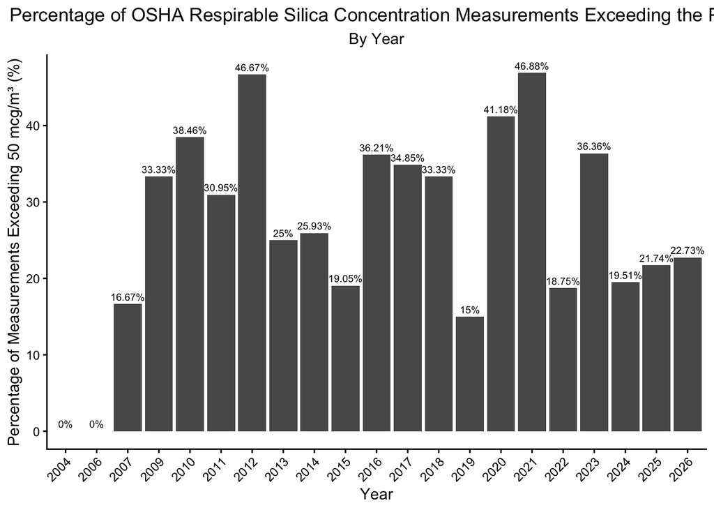

```r
ggplot(over_PEL, aes(year, annual_pct_over_pel))+
  geom_col()+
  labs(x = "Year", y = "Percentage of Measurements Exceeding 50 mcg/m³ (%)")+
  ggtitle("Percentage of OSHA Respirable Silica Concentration Measurements Exceeding the PEL", subtitle = "By Year" )+

 geom_text(aes(label = paste0(annual_pct_over_pel, "%"), vjust = -0.5), size = 2.5)+

   theme_classic()+

  theme(plot.title = element_text(hjust = 0.5),
    plot.subtitle = element_text(hjust = 0.5),
    axis.text.x = element_text(angle = 45, hjust = 1))
```

# 3 IQR by Year

Next, let’s get a table with the IQR and other study statistics for each year:

```r
descriptive_table <- study_dat |>
  group_by(year) |>
  summarize(
    n = n(),
    Mean = round(mean(silica_conc),2),
    SD = round(sd(silica_conc),2),
    IQR = round(IQR(silica_conc),2)
    )

descriptive_table
```

```
## # A tibble: 21 × 5
##    year      n  Mean    SD   IQR
##    <fct> <int> <dbl> <dbl> <dbl>
##  1 2004      2   0     0     0
##  2 2006      2   0     0     0
##  3 2007      6  28.6  43.1  38.8
##  4 2009      3  24.2  42.0  36.4
##  5 2010     26 172.  286.  291.
##  6 2011     84  64.8 112.   65.7
##  7 2012     75 141.  233.  154.
##  8 2013     68  91.9 306.   52.6
##  9 2014     54  47.4  94.0  51.3
## 10 2015     21  89.5 237.   44.2
## # ℹ 11 more rows
```

# 4 Establishment Effect

What about how many establishments are the same?

```r
study_dat |>
  group_by(establishment) |>
  count() |>
  filter(n>1)
```

```
## # A tibble: 268 × 2
## # Groups:   establishment [268]
##    establishment                               n
##    <chr>                                   <int>
##  1 101 COUNTERTOPS                             2
##  2 ABSOLUTE GRANITE PCB LLC                    2
##  3 ADP SURFACES INC                            3
##  4 AFFORDABLE GRANITE AND MARBLE LLC           2
##  5 ALABAMA MARBLE COMPANY CO INC               3
##  6 ALCO PRODUCTS INC                           3
##  7 ALL GRANITE AND MARBLE CORP                 5
##  8 ALL GRANITE AND MARBLE CORPORATION          3
##  9 ALL MARBLE GRANITE AND TILE IMPORTS INC     3
## 10 ALLIED STONE INC                            6
## # ℹ 258 more rows
```

```r
library(stringdist)
standardize_establishment <- function(x) {
  x |>
    str_squish() |>                          # trim + collapse internal whitespace
    str_to_upper() |>
    str_replace_all("&", "AND") |>           # unify ampersand vs "AND"
    str_replace_all("[[:punct:]]", "") |>    # strip periods, commas, hyphens, etc.
    str_squish()                             # re-squish in case punctuation removal left double spaces
}
study_dat <- study_dat |> mutate(establishment = standardize_establishment(establishment))


study_dat |>
  group_by(establishment) |>
  count() |>
  filter(n>1)
```

```
## # A tibble: 268 × 2
## # Groups:   establishment [268]
##    establishment                               n
##    <chr>                                   <int>
##  1 101 COUNTERTOPS                             2
##  2 ABSOLUTE GRANITE PCB LLC                    2
##  3 ADP SURFACES INC                            3
##  4 AFFORDABLE GRANITE AND MARBLE LLC           2
##  5 ALABAMA MARBLE COMPANY CO INC               3
##  6 ALCO PRODUCTS INC                           3
##  7 ALL GRANITE AND MARBLE CORP                 5
##  8 ALL GRANITE AND MARBLE CORPORATION          3
##  9 ALL MARBLE GRANITE AND TILE IMPORTS INC     3
## 10 ALLIED STONE INC                            6
## # ℹ 258 more rows
```

```r
study_dat |>
  group_by(establishment) |>
  count()
```

```
## # A tibble: 340 × 2
## # Groups:   establishment [340]
##    establishment                               n
##    <chr>                                   <int>
##  1 101 COUNTERTOPS                             2
##  2 A1 STONE WORLD INC                          1
##  3 ABBEY FABRICATION AND INSTALLATIONS LLC     1
##  4 ABSOLUTE GRANITE PCB LLC                    2
##  5 ADP SURFACES INC                            3
##  6 ADVANTA GRANITE AND STONE LLC               1
##  7 AFFORDABLE GRANITE AND MARBLE LLC           2
##  8 ALABAMA MARBLE COMPANY CO INC               3
##  9 ALCO PRODUCTS INC                           3
## 10 ALL GRANITE AND MARBLE CORP                 5
## # ℹ 330 more rows
```

Going through the list, FORTUNATELY only one establishment appears to be the same: 1. “ALL GRANITE AND MARBLE CORP” and “ALL GRANITE AND MARBLE CORPORATION”

Let’s look at how the establishments change the distribution of silica:

```r
multiple_obs <- study_dat |>
  group_by(establishment) |>
  count() |>
  filter(n>1) |>
  pull(establishment)

study_dat |>
  filter(establishment %in% multiple_obs) |>
  group_by(establishment) |>
  summarize(mean = round(mean(silica_conc), 2), sd = round(sd(silica_conc), 2))
```

```
## # A tibble: 268 × 3
##    establishment                             mean     sd
##    <chr>                                    <dbl>  <dbl>
##  1 101 COUNTERTOPS                          32.8   15.6
##  2 ABSOLUTE GRANITE PCB LLC                 40.2   56.9
##  3 ADP SURFACES INC                          5.23   9.06
##  4 AFFORDABLE GRANITE AND MARBLE LLC        12.9    1.27
##  5 ALABAMA MARBLE COMPANY CO INC             0      0
##  6 ALCO PRODUCTS INC                         6.1   10.6
##  7 ALL GRANITE AND MARBLE CORP               2.96   6.62
##  8 ALL GRANITE AND MARBLE CORPORATION      149.   104.
##  9 ALL MARBLE GRANITE AND TILE IMPORTS INC  14.1   12.4
## 10 ALLIED STONE INC                         22.6   49.4
## # ℹ 258 more rows
```

We can see that there is a lot of individual variation in the data. We can also assume that some of these are being skewed by really dramatic outliers (take, for example, CL Granite and marble llc, whose mean silica is 1,376 with an sd of 2,478.07).

# 5 Sequential modeling

Let’s start fitting our time series model to this data. We will start with a simple model that looks at the association between year and the silica conc:

```r
mod_linear_reg <- glm(silica_conc ~ year, data = study_dat)
summary(mod_linear_reg)
```

```
##
## Call:
## glm(formula = silica_conc ~ year, data = study_dat)
##
## Coefficients:
##               Estimate Std. Error t value Pr(>|t|)
## (Intercept) -1.562e-11  2.562e+02   0.000    1.000
## year2006     1.413e-11  3.623e+02   0.000    1.000
## year2007     2.855e+01  2.958e+02   0.097    0.923
## year2009     2.425e+01  3.307e+02   0.073    0.942
## year2010     1.724e+02  2.659e+02   0.649    0.517
## year2011     6.485e+01  2.592e+02   0.250    0.803
## year2012     1.408e+02  2.596e+02   0.542    0.588
## year2013     9.192e+01  2.599e+02   0.354    0.724
## year2014     4.737e+01  2.609e+02   0.182    0.856
## year2015     8.952e+01  2.681e+02   0.334    0.739
## year2016     1.710e+02  2.606e+02   0.656    0.512
## year2017     6.926e+01  2.600e+02   0.266    0.790
## year2018     1.525e+02  2.604e+02   0.585    0.558
## year2019     4.267e+01  2.625e+02   0.163    0.871
## year2020     2.605e+02  2.636e+02   0.988    0.323
## year2021     1.160e+02  2.641e+02   0.439    0.661
## year2022     4.735e+01  2.615e+02   0.181    0.856
## year2023     3.205e+02  2.600e+02   1.232    0.218
## year2024     6.196e+01  2.577e+02   0.240    0.810
## year2025     6.291e+01  2.590e+02   0.243    0.808
## year2026     4.771e+01  2.619e+02   0.182    0.856
##
## (Dispersion parameter for gaussian family taken to be 131260.6)
##
##     Null deviance: 140342828  on 1044  degrees of freedom
## Residual deviance: 134410817  on 1024  degrees of freedom
## AIC: 15304
##
## Number of Fisher Scoring iterations: 2
```

That gave us the trend when year is a character variable. Since we are missing 2005, we may need to initalize our data at year 2005. Then we can create a year counter for the year in the study, and estimate a numeric result:

### 5.0.1 Year Counter Creaqtion

```r
dat_clean <- study_dat |>
  mutate(year = as.numeric(as.character(year))) |>
  arrange(year) |>
  mutate(year_counter = dense_rank(year) - 1)

dat_clean |>
  distinct(year, year_counter) |>
  arrange(year)
```

```
##    year year_counter
## 1  2004            0
## 2  2006            1
## 3  2007            2
## 4  2009            3
## 5  2010            4
## 6  2011            5
## 7  2012            6
## 8  2013            7
## 9  2014            8
## 10 2015            9
## 11 2016           10
## 12 2017           11
## 13 2018           12
## 14 2019           13
## 15 2020           14
## 16 2021           15
## 17 2022           16
## 18 2023           17
## 19 2024           18
## 20 2025           19
## 21 2026           20
```

## 5.1 Linear Model

Let’s try our glm again:

```r
mod_linear_reg <- glm(silica_conc ~ year_counter, data = dat_clean)
summary(mod_linear_reg)
```

```
##
## Call:
## glm(formula = silica_conc ~ year_counter, data = dat_clean)
##
## Coefficients:
##              Estimate Std. Error t value Pr(>|t|)
## (Intercept)  107.4974    29.3336   3.665  0.00026 ***
## year_counter  -0.1168     2.1634  -0.054  0.95697
## ---
## Signif. codes:  0 '***' 0.001 '**' 0.01 '*' 0.05 '.' 0.1 ' ' 1
##
## (Dispersion parameter for gaussian family taken to be 134556.5)
##
##     Null deviance: 140342828  on 1044  degrees of freedom
## Residual deviance: 140342436  on 1043  degrees of freedom
## AIC: 15311
##
## Number of Fisher Scoring iterations: 2
```

```r
extract_eq(mod_linear_reg)
```

$$E( \operatorname{silica_conc} ) = \alpha +
\beta_{1}(\operatorname{year\_counter})$$

Very interesting, this time we see a small reduction in concentration over the years, but this is VERY insignificant.

Let’s proceed investigating this, adding in our random effect for establishment to establish whether there is within-group variation:

## 5.2 Clustering on Establishment

```r
coeftest(mod_linear_reg,
         vcov = vcovCL(mod_linear_reg,
                       cluster = ~ establishment,
                       type = "HC1"))
```

```
##
## z test of coefficients:
##
##               Estimate Std. Error z value  Pr(>|z|)
## (Intercept)  107.49736   27.42141  3.9202 8.848e-05 ***
## year_counter  -0.11676    2.34330 -0.0498    0.9603
## ---
## Signif. codes:  0 '***' 0.001 '**' 0.01 '*' 0.05 '.' 0.1 ' ' 1
```

Not much has changed at all!

## 5.3 Random Effect Establishment

What if we add the random effect into the equation?

```r
library(lme4)
mod_linear_reg2 <- glmer(silica_conc ~ year_counter + (1 | establishment), data = dat_clean)
summary(mod_linear_reg2)
```

```
## Linear mixed model fit by REML ['lmerMod']
## Formula: silica_conc ~ year_counter + (1 | establishment)
##    Data: dat_clean
##
## REML criterion at convergence: 15178.1
##
## Scaled residuals:
##     Min      1Q  Median      3Q     Max
## -5.1330 -0.1666 -0.1118 -0.0374 13.7224
##
## Random effects:
##  Groups        Name        Variance Std.Dev.
##  establishment (Intercept) 46346    215.3
##  Residual                  90843    301.4
## Number of obs: 1045, groups:  establishment, 340
##
## Fixed effects:
##              Estimate Std. Error t value
## (Intercept)  112.5889    38.2974   2.940
## year_counter  -0.6199     2.8078  -0.221
##
## Correlation of Fixed Effects:
##             (Intr)
## year_countr -0.912
```

```r
extract_eq(mod_linear_reg2)
```

$$\begin{aligned}
\operatorname{silica\_conc}_{i} &\sim N \left(\alpha_{j[i]} +
\beta_{1}(\operatorname{year\_counter}), \sigma^2 \right) \\
\alpha_{j} &\sim N \left(\mu_{\alpha_{j}},
\sigma^2_{\alpha_{j}} \right)
\text{, for establishment j = 1,} \dots \text{,J}
\end{aligned}$$

### 5.3.1 Over PEL

What if we instead investigate a logistic model that investigates whether the number of facilities exceeding the PEL has changed over the years?

```r
mod_logistic  <- glm(over_PEL~year_counter, data = dat_clean,
                     family = binomial)
summary(mod_logistic)
```

```
##
## Call:
## glm(formula = over_PEL ~ year_counter, family = binomial, data = dat_clean)
##
## Coefficients:
##              Estimate Std. Error z value Pr(>|z|)
## (Intercept)  -0.45559    0.17171  -2.653  0.00797 **
## year_counter -0.03617    0.01303  -2.777  0.00549 **
## ---
## Signif. codes:  0 '***' 0.001 '**' 0.01 '*' 0.05 '.' 0.1 ' ' 1
##
## (Dispersion parameter for binomial family taken to be 1)
##
##     Null deviance: 1256.6  on 1044  degrees of freedom
## Residual deviance: 1248.9  on 1043  degrees of freedom
## AIC: 1252.9
##
## Number of Fisher Scoring iterations: 4
```

```r
extract_eq(mod_logistic)
```

$$\log\left[ \frac { P( \operatorname{over\_PEL} = \operatorname{TRUE} )
}{ 1 - P( \operatorname{over\_PEL} = \operatorname{TRUE} ) } \right] =
\alpha + \beta_{1}(\operatorname{year\_counter})$$

We should not need to control for establishment here, since we are only looking at whether the proportion of facilities over PEL changed by year, but we can add in a random effect for establishment either way:

```r
coeftest(mod_logistic,
         vcov = vcovCL(mod_logistic,
                       cluster = ~ establishment,
                       type = "HC1"))
```

```
##
## z test of coefficients:
##
##               Estimate Std. Error z value Pr(>|z|)
## (Intercept)  -0.455589   0.263172 -1.7311  0.08343 .
## year_counter -0.036168   0.018211 -1.9860  0.04703 *
## ---
## Signif. codes:  0 '***' 0.001 '**' 0.01 '*' 0.05 '.' 0.1 ' ' 1
```

Looks like it is slightly less significant, but still there! Let’s interpret our outcome more clearly:

```r
mod_log_cluster <- coeftest(mod_logistic,
         vcov = vcovCL(mod_logistic,
                       cluster = ~ establishment,
                       type = "HC1"))
mod_log_cluster
```

```
##
## z test of coefficients:
##
##               Estimate Std. Error z value Pr(>|z|)
## (Intercept)  -0.455589   0.263172 -1.7311  0.08343 .
## year_counter -0.036168   0.018211 -1.9860  0.04703 *
## ---
## Signif. codes:  0 '***' 0.001 '**' 0.01 '*' 0.05 '.' 0.1 ' ' 1
```

```r
tidy_result <- tibble(
  term = rownames(mod_log_cluster),
  estimate = exp(mod_log_cluster[,"Estimate"]),
  std.error = mod_log_cluster[, "Std. Error"],
  statistic = mod_log_cluster[, "z value"],
  p.value = mod_log_cluster[, "Pr(>|z|)"]
) %>%
  mutate(
    conf.low = exp(log(estimate) - 1.96 * std.error),
    conf.high = exp(log(estimate) + 1.96 * std.error)
  ) %>%
  select(term, estimate, conf.low, conf.high, std.error, statistic, p.value)

tidy_result |>
  mutate(across(where(is.numeric), ~round(., 3)))
```

```
## # A tibble: 2 × 7
##   term         estimate conf.low conf.high std.error statistic p.value
##   <chr>           <dbl>    <dbl>     <dbl>     <dbl>     <dbl>   <dbl>
## 1 (Intercept)     0.634    0.379      1.06     0.263     -1.73   0.083
## 2 year_counter    0.964    0.931      1        0.018     -1.99   0.047
```

It looks like we see a slight decrease in the odds of the measurements being above PEL annually, controlling for the variation of each individual establishment.

## 5.4 Random effect:

```r
mod_logistic_random  <- glmer(over_PEL~year_counter + (1 | establishment), data = dat_clean,
                     family = binomial)

summary(mod_logistic_random)
```

```
## Generalized linear mixed model fit by maximum likelihood (Laplace
##   Approximation) [glmerMod]
##  Family: binomial  ( logit )
## Formula: over_PEL ~ year_counter + (1 | establishment)
##    Data: dat_clean
##
##       AIC       BIC    logLik -2*log(L)  df.resid
##    1104.3    1119.2    -549.2    1098.3      1042
##
## Scaled residuals:
##     Min      1Q  Median      3Q     Max
## -1.7881 -0.3478 -0.2499  0.4793  3.2066
##
## Random effects:
##  Groups        Name        Variance Std.Dev.
##  establishment (Intercept) 4.678    2.163
## Number of obs: 1045, groups:  establishment, 340
##
## Fixed effects:
##              Estimate Std. Error z value Pr(>|z|)
## (Intercept)  -1.08693    0.39547  -2.748  0.00599 **
## year_counter -0.05206    0.02911  -1.788  0.07373 .
## ---
## Signif. codes:  0 '***' 0.001 '**' 0.01 '*' 0.05 '.' 0.1 ' ' 1
##
## Correlation of Fixed Effects:
##             (Intr)
## year_countr -0.840
```

```r
extract_eq(mod_logistic_random)
```

$$\begin{aligned}
\operatorname{over\_PEL}_{i} &\sim \operatorname{Binomial}(n = 1,
\operatorname{prob}_{\operatorname{over\_PEL} = 1} = \widehat{P}) \\
\log\left[\frac{\hat{P}}{1 - \hat{P}} \right] &=\alpha_{j[i]} +
\beta_{1}(\operatorname{year\_counter}) \\
\alpha_{j} &\sim N \left(\mu_{\alpha_{j}},
\sigma^2_{\alpha_{j}} \right)
\text{, for establishment j = 1,} \dots \text{,J}
\end{aligned}$$

### 5.4.1 Over Action Level

What about the odds of annual measurements exceeding the action level?

```r
dat_clean <- dat_clean |>
  mutate(over_action = silica_conc >= 25)

mod_logistic2  <- glm(over_action~year_counter, data = dat_clean,
                     family = binomial)
summary(mod_logistic2)
```

```
##
## Call:
## glm(formula = over_action ~ year_counter, family = binomial,
##     data = dat_clean)
##
## Coefficients:
##              Estimate Std. Error z value Pr(>|z|)
## (Intercept)  -0.08205    0.16071  -0.511    0.610
## year_counter -0.01300    0.01189  -1.093    0.274
##
## (Dispersion parameter for binomial family taken to be 1)
##
##     Null deviance: 1433.2  on 1044  degrees of freedom
## Residual deviance: 1432.0  on 1043  degrees of freedom
## AIC: 1436
##
## Number of Fisher Scoring iterations: 4
```

```r
extract_eq(mod_logistic2)
```

$$\log\left[ \frac { P( \operatorname{over\_action} = \operatorname{TRUE}
) }{ 1 - P( \operatorname{over\_action} = \operatorname{TRUE} ) }
\right] = \alpha + \beta_{1}(\operatorname{year\_counter})$$

```r
mod_log_cluster2 <- coeftest(mod_logistic2,
         vcov = vcovCL(mod_logistic2,
                       cluster = ~ establishment,
                       type = "HC1"))
mod_log_cluster2
```

```
##
## z test of coefficients:
##
##               Estimate Std. Error z value Pr(>|z|)
## (Intercept)  -0.082052   0.247659 -0.3313   0.7404
## year_counter -0.012996   0.017232 -0.7542   0.4507
```

```r
tidy_result2 <- tibble(
  term = rownames(mod_log_cluster2),
  estimate = exp(mod_log_cluster2[,"Estimate"]),
  std.error = mod_log_cluster2[, "Std. Error"],
  statistic = mod_log_cluster2[, "z value"],
  p.value = mod_log_cluster2[, "Pr(>|z|)"]
) %>%
  mutate(
    conf.low = exp(log(estimate) - 1.96 * std.error),
    conf.high = exp(log(estimate) + 1.96 * std.error)
  ) %>%
  select(term, estimate, conf.low, conf.high, std.error, statistic, p.value)

tidy_result2 |>
  mutate(across(where(is.numeric), ~round(., 3)))
```

```
## # A tibble: 2 × 7
##   term         estimate conf.low conf.high std.error statistic p.value
##   <chr>           <dbl>    <dbl>     <dbl>     <dbl>     <dbl>   <dbl>
## 1 (Intercept)     0.921    0.567      1.50     0.248    -0.331   0.74
## 2 year_counter    0.987    0.954      1.02     0.017    -0.754   0.451
```

There is no significant change in measurements exceeding the action level by year.

# 6 High Concentration Examinations

Examine high concentrations— are there consistencies within them??